# ML1 Lineare Regression

## Inhaltverzeichnis

- Laden der nötigen Module
- Explorative Datenanalyse
- Datenreduzierung und Aufteilung in Trainings- und Testdaten
- Einfache lineare Regression
  - Erste Schritte mit Scikit-Learn
  - Vektorisierte Implementierung der Hypothese
- Vektornormen
  - Axiome und Konvexität von Normen
  - Die p-Normen
  - Die $L_{1}$- und $L_{2}$-Normen
  - Die $L_{\infty}$- und $L_{0}$-Normen
  - Beweis, dass die p-Normen die Axiome der Vektornormen erfüllen
    - Definitheit und absolute Homogenität
    - Dreiecksungleichung
- Kostenfunktionen
  - Beweis, dass nichtnegative gewichtete Summen von Normen konvex sind
  - Mean Absolute Error (MAE) und Root Mean Squared Error (RMSE)
  - Mean Squared Error (MSE)
    - Wahrscheinlichkeitstheoretische Herleitung der MSE-Funktion
    - Konvexität der MSE-Funktion
- Die Normal Equation als analytischer Ansatz zur Parameterbestimmung
- Gradient Descent als iterativer Ansatz zur Parameterbestimmung
  - Batch Gradient Descent
  - Stochastic Gradient Descent
  - Mini-Batch Gradient Descent
  - Gegenüberstellung der Algorithmen
  - Beweis, dass der Gradient die Richtung des steilsten Aufstiegs darstellt
  - Momentum
- Polynomenregression
- Over- und Underfitting
- Multiple lineare Regression

## Laden der nötigen Module

```python
import numpy as np
import pandas as pd
import matplotlib.pyplot as plt
from mpl_toolkits import mplot3d
import seaborn as sns

#%matplotlib notebook
```

## Explorative Datenanalyse

```python
from sklearn.datasets import load_boston
boston = load_boston()
boston.keys()
```

```
dict_keys(['data', 'target', 'feature_names', 'DESCR'])
```

```python
print(boston["DESCR"])
```

```
Boston House Prices dataset
===========================

Notes
------
Data Set Characteristics:

    :Number of Instances: 506

    :Number of Attributes: 13 numeric/categorical predictive

    :Median Value (attribute 14) is usually the target

    :Attribute Information (in order):
        - CRIM     per capita crime rate by town
        - ZN       proportion of residential land zoned for lots over 25,000 sq.ft.
        - INDUS    proportion of non-retail business acres per town
        - CHAS     Charles River dummy variable (= 1 if tract bounds river; 0 otherwise)
        - NOX      nitric oxides concentration (parts per 10 million)
        - RM       average number of rooms per dwelling
        - AGE      proportion of owner-occupied units built prior to 1940
        - DIS      weighted distances to five Boston employment centres
        - RAD      index of accessibility to radial highways
        - TAX      full-value property-tax rate per $10,000
        - PTRATIO  pupil-teacher ratio by town
        - B        1000(Bk - 0.63)^2 where Bk is the proportion of blacks by town
        - LSTAT    % lower status of the population
        - MEDV     Median value of owner-occupied homes in $1000's

    :Missing Attribute Values: None

    :Creator: Harrison, D. and Rubinfeld, D.L.

This is a copy of UCI ML housing dataset.
http://archive.ics.uci.edu/ml/datasets/Housing


This dataset was taken from the StatLib library which is maintained at Carnegie Mellon University.

The Boston house-price data of Harrison, D. and Rubinfeld, D.L. 'Hedonic
prices and the demand for clean air', J. Environ. Economics & Management,
vol.5, 81-102, 1978.   Used in Belsley, Kuh & Welsch, 'Regression diagnostics
...', Wiley, 1980.   N.B. Various transformations are used in the table on
pages 244-261 of the latter.

The Boston house-price data has been used in many machine learning papers that address regression
problems.

**References**

   - Belsley, Kuh & Welsch, 'Regression diagnostics: Identifying Influential Data and Sources of Collinearity', Wiley, 1980. 244-261.
   - Quinlan,R. (1993). Combining Instance-Based and Model-Based Learning. In Proceedings on the Tenth International Conference of Machine Learning, 236-243, University of Massachusetts, Amherst. Morgan Kaufmann.
   - many more! (see http://archive.ics.uci.edu/ml/datasets/Housing)
```

```python
df = pd.DataFrame(boston["data"], columns = boston["feature_names"])
df.head()
```

|  | CRIM | ZN | INDUS | CHAS | NOX | RM | AGE | DIS | RAD | TAX | PTRATIO | B | LSTAT |
| --- | --- | --- | --- | --- | --- | --- | --- | --- | --- | --- | --- | --- | --- |
| 0 | 0.00632 | 18.0 | 2.31 | 0.0 | 0.538 | 6.575 | 65.2 | 4.0900 | 1.0 | 296.0 | 15.3 | 396.90 | 4.98 |
| 1 | 0.02731 | 0.0 | 7.07 | 0.0 | 0.469 | 6.421 | 78.9 | 4.9671 | 2.0 | 242.0 | 17.8 | 396.90 | 9.14 |
| 2 | 0.02729 | 0.0 | 7.07 | 0.0 | 0.469 | 7.185 | 61.1 | 4.9671 | 2.0 | 242.0 | 17.8 | 392.83 | 4.03 |
| 3 | 0.03237 | 0.0 | 2.18 | 0.0 | 0.458 | 6.998 | 45.8 | 6.0622 | 3.0 | 222.0 | 18.7 | 394.63 | 2.94 |
| 4 | 0.06905 | 0.0 | 2.18 | 0.0 | 0.458 | 7.147 | 54.2 | 6.0622 | 3.0 | 222.0 | 18.7 | 396.90 | 5.33 |

```python
df["MEDV"] = boston["target"]
df.head()
```

|  | CRIM | ZN | INDUS | CHAS | NOX | RM | AGE | DIS | RAD | TAX | PTRATIO | B | LSTAT | MEDV |
| --- | --- | --- | --- | --- | --- | --- | --- | --- | --- | --- | --- | --- | --- | --- |
| 0 | 0.00632 | 18.0 | 2.31 | 0.0 | 0.538 | 6.575 | 65.2 | 4.0900 | 1.0 | 296.0 | 15.3 | 396.90 | 4.98 | 24.0 |
| 1 | 0.02731 | 0.0 | 7.07 | 0.0 | 0.469 | 6.421 | 78.9 | 4.9671 | 2.0 | 242.0 | 17.8 | 396.90 | 9.14 | 21.6 |
| 2 | 0.02729 | 0.0 | 7.07 | 0.0 | 0.469 | 7.185 | 61.1 | 4.9671 | 2.0 | 242.0 | 17.8 | 392.83 | 4.03 | 34.7 |
| 3 | 0.03237 | 0.0 | 2.18 | 0.0 | 0.458 | 6.998 | 45.8 | 6.0622 | 3.0 | 222.0 | 18.7 | 394.63 | 2.94 | 33.4 |
| 4 | 0.06905 | 0.0 | 2.18 | 0.0 | 0.458 | 7.147 | 54.2 | 6.0622 | 3.0 | 222.0 | 18.7 | 396.90 | 5.33 | 36.2 |

```python
df.isnull().sum()
```

```
CRIM       0
ZN         0
INDUS      0
CHAS       0
NOX        0
RM         0
AGE        0
DIS        0
RAD        0
TAX        0
PTRATIO    0
B          0
LSTAT      0
MEDV       0
dtype: int64
```

```python
df.describe()
```

|  | CRIM | ZN | INDUS | CHAS | NOX | RM | AGE | DIS | RAD | TAX | PTRATIO | B | LSTAT | MEDV |
| --- | --- | --- | --- | --- | --- | --- | --- | --- | --- | --- | --- | --- | --- | --- |
| count | 506.000000 | 506.000000 | 506.000000 | 506.000000 | 506.000000 | 506.000000 | 506.000000 | 506.000000 | 506.000000 | 506.000000 | 506.000000 | 506.000000 | 506.000000 | 506.000000 |
| mean | 3.593761 | 11.363636 | 11.136779 | 0.069170 | 0.554695 | 6.284634 | 68.574901 | 3.795043 | 9.549407 | 408.237154 | 18.455534 | 356.674032 | 12.653063 | 22.532806 |
| std | 8.596783 | 23.322453 | 6.860353 | 0.253994 | 0.115878 | 0.702617 | 28.148861 | 2.105710 | 8.707259 | 168.537116 | 2.164946 | 91.294864 | 7.141062 | 9.197104 |
| min | 0.006320 | 0.000000 | 0.460000 | 0.000000 | 0.385000 | 3.561000 | 2.900000 | 1.129600 | 1.000000 | 187.000000 | 12.600000 | 0.320000 | 1.730000 | 5.000000 |
| 25% | 0.082045 | 0.000000 | 5.190000 | 0.000000 | 0.449000 | 5.885500 | 45.025000 | 2.100175 | 4.000000 | 279.000000 | 17.400000 | 375.377500 | 6.950000 | 17.025000 |
| 50% | 0.256510 | 0.000000 | 9.690000 | 0.000000 | 0.538000 | 6.208500 | 77.500000 | 3.207450 | 5.000000 | 330.000000 | 19.050000 | 391.440000 | 11.360000 | 21.200000 |
| 75% | 3.647423 | 12.500000 | 18.100000 | 0.000000 | 0.624000 | 6.623500 | 94.075000 | 5.188425 | 24.000000 | 666.000000 | 20.200000 | 396.225000 | 16.955000 | 25.000000 |
| max | 88.976200 | 100.000000 | 27.740000 | 1.000000 | 0.871000 | 8.780000 | 100.000000 | 12.126500 | 24.000000 | 711.000000 | 22.000000 | 396.900000 | 37.970000 | 50.000000 |

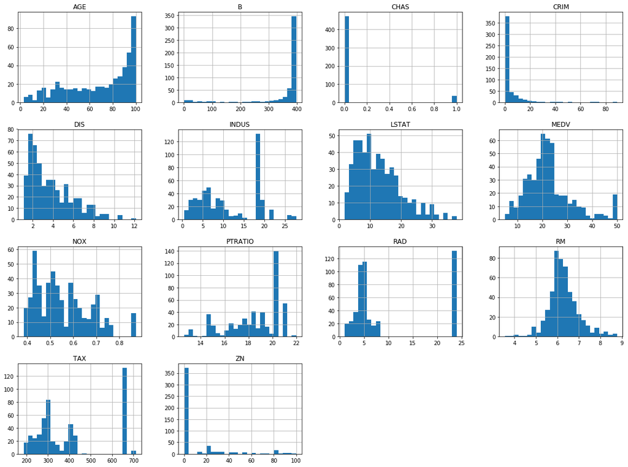

```python
df.hist(bins = 25, figsize = (20,15));
```

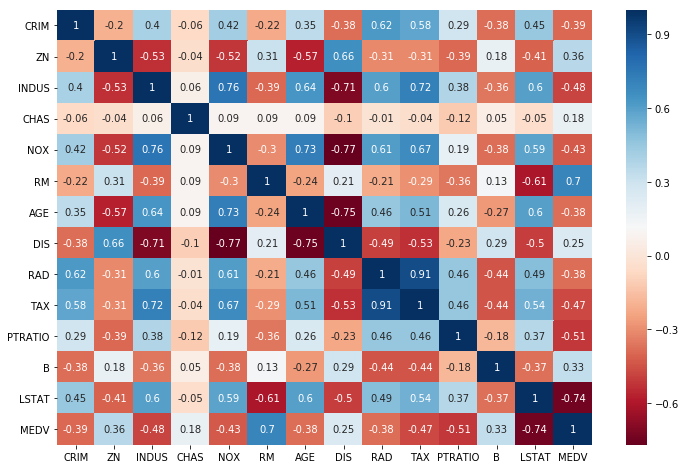

```python
plt.figure(figsize = (12, 8))

korrelationsmatrix = df.corr().round(2)
sns.heatmap(korrelationsmatrix, annot = True, cmap = "RdBu");
```

$$\vec{u}=\left[\begin{matrix}u^{(1)}\\u^{(2)}\\\vdots\\u^{(m)}\\\end{matrix}\right],\hspace{0.3cm}\vec{v}=\left[\begin{matrix}v^{(1)}\\v^{(2)}\\\vdots\\v^{(m)}\\\end{matrix}\right]\in\mathbb{R}^m$$

$$r=\frac{\sum_{i=1}^{m}\left[(u^{(i)}-\mu_u)(v^{(i)}-\mu_v)\right]}{\sqrt{\sum_{i=1}^{m}{(u^{(i)}-\mu_u)}^2}\sqrt{\sum_{i=1}^{m}{(v^{(i)}-\mu_v)}^2}}=\frac{cov(u, v)}{\sigma_u\sigma_v}$$

$$r=\frac{(\vec{u}-\mu_u)^{T}(\vec{v}-\mu_v)}{\sqrt{(\vec{u}-\mu_u)^{T}(\vec{u}-\mu_u)}\sqrt{(\vec{v}-\mu_v)^{T}(\vec{v}-\mu_v)}}$$

```python
def pearson_r(x, y):

    assert len(x) == len(y)
    xdiff = x - np.mean(x)
    ydiff = y - np.mean(y)
    cov = xdiff.dot(ydiff)
    return round(cov / (np.sqrt(xdiff.dot(xdiff)) * np.sqrt(ydiff.dot(ydiff))), 2)

print("r(RM, MEDV): ", pearson_r(df["RM"], df["MEDV"]))
print("r(LSTAT, MEDV): ", pearson_r(df["LSTAT"], df["MEDV"]))
```

```
r(RM, MEDV):  0.7
r(LSTAT, MEDV):  -0.74
```

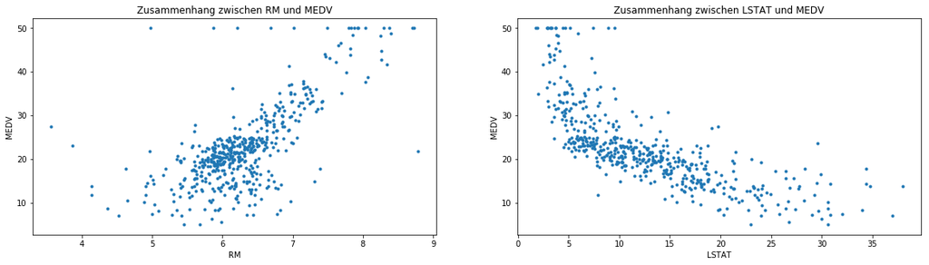

```python
features = ["RM", "LSTAT"]
target = df["MEDV"]

plt.figure(figsize = (20, 5))

for index, column in enumerate(features):
    plt.subplot(1, len(features), index + 1)
    x = df[column]
    y = target
    plt.scatter(x, y, marker = ".")
    plt.title(f"Zusammenhang zwischen {column} und MEDV")
    plt.xlabel(column)
    plt.ylabel("MEDV")
```

## Datenreduzierung und Aufteilen in Trainings- und Testdaten

```python
df_reduced = df.drop(df[df["MEDV"] == 50].index)
print(df_reduced.shape)
```

```
(490, 14)
```

```python
data = df_reduced[["RM", "LSTAT", "MEDV"]]
data.head()
```

|  | RM | LSTAT | MEDV |
| --- | --- | --- | --- |
| 0 | 6.575 | 4.98 | 24.0 |
| 1 | 6.421 | 9.14 | 21.6 |
| 2 | 7.185 | 4.03 | 34.7 |
| 3 | 6.998 | 2.94 | 33.4 |
| 4 | 7.147 | 5.33 | 36.2 |

```python
from sklearn.model_selection import train_test_split

train, test = train_test_split(data, test_size = 0.2, random_state = 0)

print(train.shape)
print(test.shape)
```

```
(392, 3)
(98, 3)
```

## Einfache lineare Regression

### Erste Schritte mit Scikit-Learn

$$\left\{(x^{(i)},y^{(i)})\ \middle|\ i=1,...,m\right\}$$

```python
X_train = np.array(train["RM"]).reshape(train["RM"].size, 1)
y_train = np.array(train["MEDV"]).reshape(train["MEDV"].size, 1)

X_test = np.array(test["RM"]).reshape(test["RM"].size, 1)
y_test = np.array(test["MEDV"]).reshape(test["MEDV"].size, 1)
```

$$y^{(i)}=\theta_0+\theta_1x^{(i)}+\varepsilon^{(i)}$$

$$h:\mathbb{R}\rightarrow\mathbb{R},\ \ x\mapsto\hat{y}$$

$$h(x^{(i)};\theta_0,\theta_1)=\theta_0+\theta_1x^{(i)}={\hat{y}}^{(i)}$$

$${\hat{y}}^{(i)}\approx y^{(i)}$$

```python
from sklearn.linear_model import LinearRegression

modell = LinearRegression(fit_intercept = True)
modell.fit(X_train, y_train)

print(f"Y-Achsenabschnitt: {round(modell.intercept_[0], 3)}")
print(f"Koeffizient: {round(modell.coef_[0][0], 3)}")
```

```
Y-Achsenabschnitt: -30.281
Koeffizient: 8.314
```

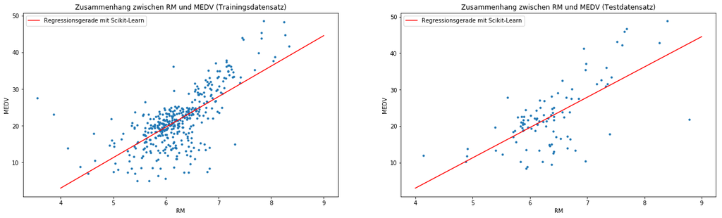

```python
fig, (ax1, ax2) = plt.subplots(1, 2, figsize=(22, 6))

x_ = np.arange(4, 10).reshape(6, 1)
y_ = modell.predict(x_)

ax1.scatter(train["RM"], train["MEDV"], marker = ".", label = None)
ax1.plot(x_, y_, color = "red", label = "Regressionsgerade mit Scikit-Learn")
ax2.scatter(test["RM"], test["MEDV"], marker = ".", label = None)
ax2.plot(x_, y_, color = "red", label = "Regressionsgerade mit Scikit-Learn")

ax1.set_title("Zusammenhang zwischen RM und MEDV (Trainingsdatensatz)")
ax2.set_title("Zusammenhang zwischen RM und MEDV (Testdatensatz)")
ax1.set_xlabel("RM"); ax2.set_xlabel("RM")
ax1.set_ylabel("MEDV"); ax2.set_ylabel("MEDV")
ax1.legend(); ax2.legend();
```

$$\vec{\varepsilon}=\left[\begin{matrix}{\hat{y}}^{(1)}-y^{(1)}\\{\hat{y}}^{(2)}-y^{(2)}\\\vdots\\{\hat{y}}^{(m)}-y^{(m)}\\\end{matrix}\right]\ =\left[\begin{matrix}{\hat{\varepsilon}}^{(1)}\\{\hat{\varepsilon}}^{(2)}\\\vdots\\{\hat{\varepsilon}}^{(m)}\\\end{matrix}\right]\ \in\mathbb{R}^m$$

```python
epsilon_train = modell.predict(X_train) - y_train
epsilon_test = modell.predict(X_test) - y_test
```

### Vektorisierte Implementierung der Hypothese

$$h\left({\vec{x}}^{\left(i\right)};\vec{\theta}\right)=\theta_0x_0^{\left(i\right)}+\theta_1x_1^{\left(i\right)}={\hat{y}}^{\left(i\right)}$$

$$\hspace{0.2cm}{\vec{x}}^{(i)}=\left[\begin{matrix}x_0^{(i)}=1\\x_1^{(i)}\\\end{matrix}\right]\in\mathbb{R}^2,\hspace{0.2cm}\vec{\theta}=\left[\begin{matrix}\theta_0\\\theta_1\\\end{matrix}\right]\in\mathbb{R}^2$$

$$h({\vec{x}}^{(i)};\vec{\theta})=\sum_{j=0}^{1}\theta_jx_j^{(i)}={\vec{\theta}}^T{\vec{x}}^{(i)}$$

$$h\left({\vec{x}}^{\left(i\right)};\vec{\theta}\right)=\theta_0x_0^{\left(i\right)}+\theta_1x_1^{\left(i\right)}+\theta_2x_2^{\left(i\right)}+\ldots+\theta_nx_n^{\left(i\right)}={\hat{y}}^{\left(i\right)}$$

$$\left({\vec{x}}^{\left(i\right)};\vec{\theta}\right)=\sum_{j=0}^{n}\theta_jx_j^{(i)}={\vec{\theta}}^T{\vec{x}}^{(i)}$$

$$h:\mathbb{R}^{n+1}\rightarrow\mathbb{R},\ \ \vec{x}\mapsto\hat{y}$$

$$X=\left[\begin{matrix}{{\vec{x}}^{(1)T}}\\{{\vec{x}}^{(2)T}}\\\vdots\\{{\vec{x}}^{(m)T}}\\\end{matrix}\right]\in\mathbb{R}^{m\ \times\ n+1}$$

$$\vec{y}=\left[\begin{matrix}y^{(1)}\\y^{(2)}\\\vdots\\y^{(m)}\\\end{matrix}\right]\in\mathbb{R}^m$$

$$X\vec{\theta}-\vec{y}=\left[\begin{matrix}{{\vec{x}}^{\left(1\right)T}}\vec{\theta}\\{{\vec{x}}^{\left(2\right)T}}\vec{\theta}\\\vdots\\{{\vec{x}}^{\left(m\right)T}}\vec{\theta}\\\end{matrix}\right]-\left[\begin{matrix}y^{\left(1\right)}\\y^{\left(2\right)}\\\vdots\\y^{\left(m\right)}\\\end{matrix}\right]=\left[\begin{matrix}{\hat{y}}^{(1)}-y^{(1)}\\{\hat{y}}^{(2)}-y^{(2)}\\\vdots\\{\hat{y}}^{(m)}-y^{(m)}\\\end{matrix}\right]\ =\left[\begin{matrix}{\hat{\varepsilon}}^{(1)}\\{\hat{\varepsilon}}^{(2)}\\\vdots\\{\hat{\varepsilon}}^{(m)}\\\end{matrix}\right]=\vec{\varepsilon}$$

## Vektornormen

### Axiome und Konvexität von Normen

Eine Norm ist eine Funktion, die vom Vektorraum $\mathbb{R}^n$ auf die Menge der nichtnegativen reellen Zahlen abbildet.

$$||·||:\mathbb{R}^n\rightarrow\mathbb{R}_0^+,\hspace{0.2cm}\vec{v}\mapsto||\vec{v}||$$

Ferner gelten folgende Axiome für Normen:

1. $\forall\vec{v}\in\mathbb{R}^n:||\vec{v}||=0\Rightarrow\vec{v}=0\hspace{0.4cm}$(Definitheit)
2. $\forall\vec{v}\in\mathbb{R}^n,\lambda\in\mathbb{R}∶||\lambda·\vec{v}||=\left|\lambda\right|·||\vec{v}||\hspace{0.4cm}$(Absolute Homogenität)
3. $\forall\vec{u},\vec{v}\in\mathbb{R}^n:||\vec{u}+\vec{v}||\le||\vec{u}||+||\vec{v}||\hspace{0.4cm}$(Dreiecksungleichung)

Eine Funktion $f:\mathbb{R}^n\rightarrow\mathbb{R}$ heißt konvex $:\Leftrightarrow\forall\vec{u},\vec{v}\in\ \mathbb{R}^n,\lambda\in[0,1]:f(\lambda\vec{u}+(1-\lambda)\vec{v})\le\lambda\ f(\vec{u})+(1-\lambda)f(\vec{v})$

Aus der Dreiecksungleichung und der absoluten Homogenität geht die Konvexität von Normen hervor:

$$\forall\vec{u},\vec{v}\in\mathbb{R}^n,\lambda\in[0,1]:||\lambda\vec{u}+(1-\lambda)\vec{v}||\le||\lambda\vec{u}||+||(1-\lambda)\vec{v}||=\lambda||\vec{u}||+(1-\lambda)||\vec{v}||$$

### Die p-Normen

$$||\vec{v}||_{p}:=\left(\sum_{i=1}^{m}\left|{{v}}^{(i)}\right|^p\right)^\frac{1}{p},\hspace{0.4cm}\vec{v}=\left[\begin{matrix}v^{(1)}\\\begin{matrix}v^{(2)}\\\vdots\\\end{matrix}\\v^{(m)}\\\end{matrix}\right]$$

### Die $L_{1}$- und $L_{2}$-Normen

$$||\vec{v}||_{1}=\sum_{i=1}^{m}\left|{v}^{(i)}\right|$$

```python
def l1(vector):
        return np.sum(np.abs(vector))

print("L1-Norm des Trainingsfehlervektors: ", round(l1(epsilon_train), 2))
print("L1-Norm des Testfehlervektors: ", round(l1(epsilon_test), 2))
```

```
L1-Norm des Trainingsfehlervektors:  1538.4
L1-Norm des Testfehlervektors:  473.88
```

```python
def plot_norm(norm):

    x = np.linspace(-1, 1, 30)
    y = np.linspace(-1, 1, 30)

    X, Y = np.meshgrid(x, y)
    Z = norm(X, Y)

    fig = plt.figure(figsize=(11,6))
    ax  = plt.axes(projection = "3d")
    ax.plot_surface(X, Y, Z, rstride=1, cstride=1, cmap="bwr", edgecolor="none")
    ax.xaxis.set_major_locator(plt.MaxNLocator(5))
    ax.yaxis.set_major_locator(plt.MaxNLocator(5))
    ax.zaxis.set_major_locator(plt.MaxNLocator(5))
    ax.set_xlabel("x")
    ax.set_ylabel("y")
    ax.zaxis.set_rotate_label(False)
    ax.set_zlabel("||[x,y]||");
```

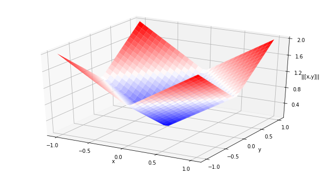

```python
l1_simplified = lambda x, y: abs(x) + abs(y)
plot_norm(l1_simplified)
```

$$||\vec{v}||_{2}=\sqrt{\sum_{i=1}^{m}{{\hat{\varepsilon}}^{(i)}}^2}$$

```python
def l2(vector):
        return np.sqrt(np.sum(vector**2))

print("L2-Norm des Trainingsfehlervektors: ", round(l2(epsilon_train), 2))
print("L2-Norm des Testfehlervektors: ", round(l2(epsilon_test), 2))
```

```
L2-Norm des Trainingsfehlervektors:  108.41
L2-Norm des Testfehlervektors:  65.09
```

```python
print("L2-Norm des Trainingsfehlervektors: ", round(np.linalg.norm(epsilon_train), 2))
print("L2-Norm des Testfehlervektors: ", round(np.linalg.norm(epsilon_test), 2))
```

```
L2-Norm des Trainingsfehlervektors:  108.41
L2-Norm des Testfehlervektors:  65.09
```

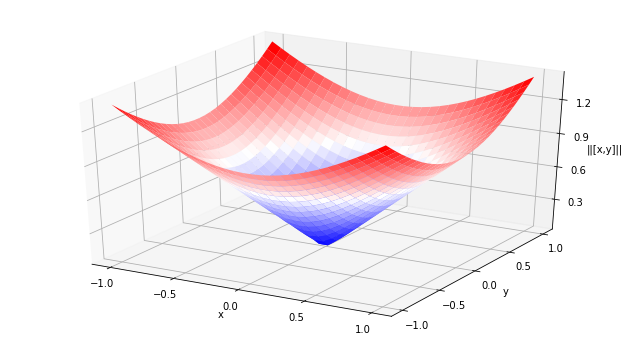

```python
l2_simplified = lambda x, y: np.sqrt(x**2 + y**2)
plot_norm(l2_simplified)
```

### Die $L_{\infty}$- und $L_{0}$-Normen

$$||\vec{v}||_{\infty}=\lim_{p\rightarrow\infty}{\left(\sum_{i=1}^{m}\left|{v}^{(i)}\right|^p\right)^\frac{1}{p}}$$

$$\lim_{p\rightarrow\infty}{\left|{v}^{(j)}\right|^p}\gg\lim_{p\rightarrow\infty}\left|{v}^{(i)}\right|^\hspace{0.4cm}\forall\ i\neq\ j$$

$$\lim_{p\rightarrow\infty}\sum_{i=1}^{m}{\left|{v}^{(i)}\right|^p=\lim_{p\rightarrow\infty}{\left|{v}^{(j)}\right|^p}}$$

$$||\vec{v}||_{\infty}={\lim_{p\rightarrow\infty}\left(\left|{v}^{(j)}\right|^p\right)}^\frac{1}{p}=\left|{v}^{(j)}\right|$$

$$||\vec{v}||_{\infty}=\underset{i}{max}\hspace{0.1cm}|v^{(i)}|$$

```python
def l_infinity(vector):
    return np.amax(vector)

print("Größter Absolutwert im Trainingsfehlervektor: ", round(l_infinity(epsilon_train), 2))
print("Größter Absolutwert Abweichung im Testfehlervektor: ", round(l_infinity(epsilon_test), 2))
```

```
Größter Absolutwert im Trainingsfehlervektor:  18.61
Größter Absolutwert Abweichung im Testfehlervektor:  20.82
```

$$||\vec{v}||_{0}:=\sum_{i=1}^{m}1_{v^{(i)}\neq0}$$

$$\forall\vec{v}\in\mathbb{R}^n,\lambda\in\mathbb{R}\setminus\left\{0,1\right\}:||\lambda·\vec{v}||\neq\left|\lambda\right|·||\vec{v}||$$

```python
def l0(vector):
    return np.count_nonzero(vector)

print("Anzahl der Nichtnulleinträge im Trainingsfehlervektor: ", l0(epsilon_train))
print("Anzahl der Nichtnulleinträge im Testfehlervektor: ", l0(epsilon_test))
```

```
Anzahl der Nichtnulleinträge im Trainingsfehlervektor:  392
Anzahl der Nichtnulleinträge im Testfehlervektor:  98
```

### Beweis, dass die p-Normen die Axiome der Vektornormen erfüllen

#### Definitheit und absolute Homogenität

$$ \forall\vec{v}\in\mathbb{R}^n:||\vec{v}||_{p}=0\Leftrightarrow\left(\sum_{i=1}^{m}\left|v^{(i)}\right|^p\right)^\frac{1}{p}=0\Rightarrow\sum_{i=1}^{m}\left|v^{(i)}\right|^p=0\Rightarrow\vec{v}=\left[\begin{matrix}0\\\vdots\\0\\\end{matrix}\right]=0 $$

$$ \forall\vec{v}\in\mathbb{R}^n:||\lambda\vec{v}||_{p}=\left(\sum_{i=1}^{m}\left|{\lambda v}^{(i)}\right|^p\right)^\frac{1}{p}=\left(\sum_{i=1}^{m}{\left|\lambda\right|^p\left|v^{(i)}\right|^p}\right)^\frac{1}{p}=\left|\lambda\right|\left(\sum_{i=1}^{m}\left|v^{(i)}\right|^p\right)^\frac{1}{p}=\left|\lambda\right|·||\vec{v}||_{p}$$

## Kostenfunktionen

### Beweis, dass nichtnegative gewichtete Summen von Normen konvex sind

Seien $f_{1},...,f_{n}$ konvexe Funktionen und $\omega_{1},...,\omega_{n}\geq0$, dann ist $f(x)=\omega_{1}f_{1}(x)+...+\omega_{n}f_{n}(x)$ ebenfalls konvex.

$$f(\lambda\vec{u}+(1-\lambda)\vec{v})=\omega_1f_1(\lambda\vec{u}+(1-\lambda)\vec{v})+...+\omega_nf_n(\lambda\vec{u}+(1-\lambda)\vec{v})\le$$$$\omega_1({\lambda f}_1(\vec{u})+(1-\lambda)f_1(\vec{v}))+...+\omega_n({\lambda f}_n(\vec{u})+(1-\lambda)f_n(\vec{v}))$$$$=\lambda(\omega_1f_1(\vec{u})+...+\omega_nf_n(\vec{u})))+(1-\lambda)(\omega_1f_1(\vec{v})+...+\omega_nf_n(\vec{v}))$$$$=\lambda\ f(\vec{u})+(1-\lambda)f(\vec{v})$$

### Mean Absolute Error (MAE) und Root Mean Squared Error (RMSE)

$$MAE=\frac{1}{m}\sum_{i=1}^{m}\left|{\hat{y}}^{(i)}-y^{(i)}\right|=\frac{1}{m}||\vec{\varepsilon}||_{1}$$

```python
def MAE(vector):
    return l1(vector)/len(vector)

print("MAE des Trainingsfehlervektors: ", round(MAE(epsilon_train), 2))
print("MAE des Testfehlervektors: ", round(MAE(epsilon_test), 2))
```

```
MAE des Trainingsfehlervektors:  3.92
MAE des Testfehlervektors:  4.84
```

$$RMSE\ =\ \sqrt{\frac{1}{m}\sum_{i=1}^{m}{({\hat{y}}^{(i)}-y^{(i)})}^2}=\frac{1}{\sqrt m}||\vec{\varepsilon}||_{2}$$

```python
def RMSE(vector):
    return l2(vector)/np.sqrt(len(vector))

print("RMSE des Trainingsfehlervektors: ", round(RMSE(epsilon_train), 2))
print("RMSE des Testfehlervektors: ", round(RMSE(epsilon_test), 2))
```

```
RMSE des Trainingsfehlervektors:  5.48
RMSE des Testfehlervektors:  6.57
```

### Mean Squared Error (MSE)

#### Wahrscheinlichkeitstheoretische Herleitung der MSE-Funktion

$$y^{(i)}=h({\vec{x}}^{(i)};\vec{\theta})+\varepsilon^{(i)}$$

$$\varepsilon^{\left(i\right)}\sim N\left(0,\sigma^2\right)$$

$$wdf(\varepsilon^{\left(i\right)})=\frac{1}{\sqrt{2\pi}\sigma}exp\left(-\frac{{{\varepsilon}^{\left(i\right)}}^2}{2\sigma^2}\right)$$

$$\varepsilon^{(i)}=y^{(i)}-h({\vec{x}}^{(i)};\vec{\theta})$$

$$y^{(i)}|\hspace{0.1cm}{\vec{x}}^{(i)};\vec{\theta}\sim N\left(h({\vec{x}}^{(i)};\vec{\theta}),\sigma^2\right)$$

$$wdf(y^{(i)}|\hspace{0.1cm}{\vec{x}}^{(i)};\vec{\theta})=\frac{1}{\sqrt{2\pi}\sigma}exp\left(-\frac{{(y^{(i)}-h({\vec{x}}^{(i)};\vec{\theta}))}^2}{2\sigma^2}\right)$$

$$L(\vec{\theta})=\prod_{i=1}^{m}{wdf(y^{(i)}|\hspace{0.1cm}{\vec{x}}^{(i)};\vec{\theta})=\prod_{i=1}^{m}{\frac{1}{\sqrt{2\pi}\sigma}exp\left(-\frac{{(y^{(i)}-h({\vec{x}}^{(i)};\vec{\theta}))}^2}{2\sigma^2}\right)}}$$

$$\underset{\vec{\theta}}{max}\hspace{0.1cm}{L(\vec{\theta})}$$

$$l(\vec{\theta})=\log{L(\vec{\theta})}=\log\prod_{i=1}^{m}{\frac{1}{\sqrt{2\pi}\sigma}exp\left(-\frac{{(y^{(i)}-h({\vec{x}}^{(i)};\vec{\theta}))}^2}{2\sigma^2}\right)}$$$$=\sum_{i=1}^{m}\log\left[\frac{1}{\sqrt{2\pi}\sigma}exp\left(-\frac{{(y^{(i)}-h({\vec{x}}^{(i)};\vec{\theta}))}^2}{2\sigma^2}\right)\right]$$$$=m· \log\frac{1}{\sqrt{2\pi}\sigma}+\sum_{i=1}^{m}{-\frac{{(y^{(i)}-h({\vec{x}}^{(i)};\vec{\theta}))}^2}{2\sigma^2}}$$$$=m· \log\frac{1}{\sqrt{2\pi}\sigma}-\frac{1}{\sigma^2}·\frac{1}{2}\sum_{i=1}^{m}{(y^{(i)}-h({\vec{x}}^{(i)};\vec{\theta}))}^2$$

#### Konvexität der MSE-Funktion

$$J(\vec{\theta})=\frac{1}{2}||\vec{\varepsilon}||_{2}^{2}$$

$$\nabla J(\vec{\theta})=\left[\begin{matrix}\frac{\partial J\left(\vec{\theta}\right)}{\partial\theta_0}\\\frac{\partial J\left(\vec{\theta}\right)}{\partial\theta_1}\\\vdots\\\frac{\partial J\left(\vec{\theta}\right)}{\partial\theta_n}\\\end{matrix}\right]=\left[\begin{matrix}\begin{matrix}\sum_{i=1}^{m}\left(\sum_{j=0}^{n}\theta_jx_j^{(i)}-y^{(i)}\right)x_0^{(i)}\\\sum_{i=1}^{m}\left(\sum_{j=0}^{n}\theta_jx_j^{(i)}-y^{(i)}\right)x_1^{(i)}\\\end{matrix}\\\vdots\\\sum_{i=1}^{m}\left(\sum_{j=0}^{n}\theta_jx_j^{(i)}-y^{(i)}\right)x_n^{(i)}\\\end{matrix}\right]=\left[\begin{matrix}\begin{matrix}\sum_{i=1}^{m}{{\hat{\varepsilon}}^{(i)}x}_0^{(i)}\\\sum_{i=1}^{m}{{\hat{\varepsilon}}^{(i)}x}_1^{(i)}\\\end{matrix}\\\vdots\\\sum_{i=1}^{m}{{\hat{\varepsilon}}^{(i)}x}_n^{(i)}\\\end{matrix}\right]=X^T(X\vec{\theta}-\vec{y})\in\mathbb{R}^{n+1}$$

$$\nabla^2J(\vec{\theta})=\left[\begin{matrix}\begin{matrix}\begin{matrix}\frac{\partial J(\vec{\theta})}{\partial{\theta_0}^2}&\frac{\partial J(\vec{\theta})}{\partial\theta_0\theta_1}\\\end{matrix}&...&\frac{\partial J(\vec{\theta})}{\partial\theta_0\theta_n}\\\end{matrix}\\\begin{matrix}\begin{matrix}\frac{\partial J(\vec{\theta})}{\partial\theta_1\theta_0}&\frac{\partial J(\vec{\theta})}{\partial{\theta_1}^2}\\\end{matrix}&...&\frac{\partial J(\vec{\theta})}{\partial\theta_1\theta_n}\\\end{matrix}\\\vdots\\\begin{matrix}\begin{matrix}\frac{\partial J(\vec{\theta})}{\partial\theta_n\theta_0}&\frac{\partial J(\vec{\theta})}{\partial\theta_n\theta_1}\\\end{matrix}&...&\frac{\partial J(\vec{\theta})}{\partial{\theta_n}^2}\\\end{matrix}\\\end{matrix}\right]=\left[\begin{matrix}\begin{matrix}\begin{matrix}\sum_{i=1}^{m}{x_0^{(i)}}^2&\sum_{i=1}^{m}{x_0^{(i)}x_1^{(i)}}\\\end{matrix}&...&\sum_{i=1}^{m}{x_0^{(i)}x_n^{(i)}}\\\end{matrix}\\\begin{matrix}\begin{matrix}\sum_{i=1}^{m}{x_1^{(i)}x_0^{(i)}}&\sum_{i=1}^{m}{x_1^{(i)}}^2\\\end{matrix}&...&\sum_{i=1}^{m}{x_1^{(i)}x_n^{(i)}}\\\end{matrix}\\\vdots\\\begin{matrix}\begin{matrix}\sum_{i=1}^{m}{x_n^{(i)}x_0^{(i)}}&\sum_{i=1}^{m}{x_n^{(i)}x_1^{(i)}}\\\end{matrix}&...&\sum_{i=1}^{m}{x_n^{(i)}}^2\\\end{matrix}\\\end{matrix}\right]=X^TX\in\mathbb{R}^{n+1\ \times\ n+1}$$

Wir wollen zeigen, dass die Hesse-Matrix $X^TX\succcurlyeq0$, also positiv semidefinit ist.

Eine $(k \times k)$-Matrix $A$ heißt positiv semidefinit $:\Leftrightarrow\forall\vec{v}\in\mathbb{R}^k,\vec{v}\neq0:\ {\vec{v}}^TA\vec{v}\geq0$

Wir zeigen also, dass $\forall\vec{v}\in\mathbb{R}^{n+1},\vec{v}\neq0:{\vec{v}}^TX^TX\vec{v}\geq0$

$${\vec{v}}^TX^TX\vec{v}=\left(X\vec{v}\right)^T\left(X\vec{v}\right)=||X\vec{v}||_{2}^{2}\geq0$$

## Die Normal Equation als analytischer Ansatz zur Parameterbestimmung

$$J(\vec{\theta})={(X\vec{\theta}-\vec{y})}^T(X\vec{\theta}-\vec{y})$$$$=({(X\vec{\theta})}^T-{\vec{y}}^T)(X\vec{\theta}-\vec{y})$$$$={(X\vec{\theta})}^T(X\vec{\theta})-{(X\vec{\theta})}^T(\vec{y})-{(\vec{y})}^T(X\vec{\theta})-{(\vec{y})}^T(\vec{y})$$$$={\vec{\theta}}^TX^TX\vec{\theta}-{2(X\vec{\theta})}^T\vec{y}-{\vec{y}}^T\vec{y}$$

$$P(\vec{\theta})={\vec{\theta}}^TX^TX\vec{\theta}$$$$Q(\vec{\theta})={2(X\vec{\theta})}^T\vec{y}$$$$\nabla J(\vec{\theta})=\nabla P(\vec{\theta})-\nabla Q(\vec{\theta})$$

$$P(\vec{\theta})=\left[\begin{matrix}\theta_0&\theta_1&\begin{matrix}...&\theta_n\\\end{matrix}\\\end{matrix}\right]\left[\begin{matrix}\begin{matrix}\begin{matrix}x_0^{(1)}&x_0^{(2)}\\\end{matrix}&...&x_0^{(m)}\\\end{matrix}\\\begin{matrix}\begin{matrix}x_1^{(1)}&x_1^{(2)}\\\end{matrix}&...&x_1^{(m)}\\\end{matrix}\\\vdots\\\begin{matrix}\begin{matrix}x_n^{(1)}&x_n^{(2)}\\\end{matrix}&...&x_n^{(m)}\\\end{matrix}\\\end{matrix}\right]\left[\begin{matrix}\begin{matrix}\begin{matrix}x_0^{(1)}&x_1^{(1)}\\\end{matrix}&...&x_n^{(1)}\\\end{matrix}\\\begin{matrix}\begin{matrix}x_0^{(2)}&x_1^{(2)}\\\end{matrix}&...&x_n^{(2)}\\\end{matrix}\\\vdots\\\begin{matrix}\begin{matrix}x_0^{(m)}&x_1^{(m)}\\\end{matrix}&...&x_n^{(m)}\\\end{matrix}\\\end{matrix}\right]\left[\begin{matrix}\theta_0\\\theta_1\\\vdots\\\theta_n\\\end{matrix}\right]$$

$$X^TX=X^2=\left[\begin{matrix}\begin{matrix}\begin{matrix}\sum_{i=1}^{m}{x_0^{(i)}}^2&\sum_{i=1}^{m}{x_0^{(i)}x_1^{(i)}}\\\end{matrix}&...&\sum_{i=1}^{m}{x_0^{(i)}x_n^{(i)}}\\\end{matrix}\\\begin{matrix}\begin{matrix}\sum_{i=1}^{m}{x_1^{(i)}x_0^{(i)}}&\sum_{i=1}^{m}{x_1^{(i)}}^2\\\end{matrix}&...&\sum_{i=1}^{m}{x_1^{(i)}x_n^{(i)}}\\\end{matrix}\\\vdots\\\begin{matrix}\begin{matrix}\sum_{i=1}^{m}{x_n^{(i)}x_0^{(i)}}&\sum_{i=1}^{m}{x_n^{(i)}x_1^{(i)}}\\\end{matrix}&...&\sum_{i=1}^{m}{x_n^{(i)}}^2\\\end{matrix}\\\end{matrix}\right]=\left[\begin{matrix}\begin{matrix}\begin{matrix}X_{0,0}^2&X_{0,1}^2\\\end{matrix}&...&X_{0,n}^2\\\end{matrix}\\\begin{matrix}\begin{matrix}X_{1,0}^2&X_{1,1}^2\\\end{matrix}&...&X_{1,n}^2\\\end{matrix}\\\vdots\\\begin{matrix}\begin{matrix}X_{n,0}^2&X_{n,1}^2\\\end{matrix}&...&X_{n,n}^2\\\end{matrix}\\\end{matrix}\right]$$

$$P(\vec{\theta})={\vec{\theta}}^TX^2\vec{\theta}=\left[\begin{matrix}\theta_0&\theta_1&\begin{matrix}...&\theta_n\\\end{matrix}\\\end{matrix}\right]\left[\begin{matrix}\begin{matrix}\begin{matrix}X_{0,0}^2&X_{0,1}^2\\\end{matrix}&...&X_{0,n}^2\\\end{matrix}\\\begin{matrix}\begin{matrix}X_{1,0}^2&X_{1,1}^2\\\end{matrix}&...&X_{1,n}^2\\\end{matrix}\\\vdots\\\begin{matrix}\begin{matrix}X_{n,0}^2&X_{n,1}^2\\\end{matrix}&...&X_{n,n}^2\\\end{matrix}\\\end{matrix}\right]\left[\begin{matrix}\theta_0\\\theta_1\\\vdots\\\theta_n\\\end{matrix}\right]$$

$$P\left(\vec{\theta}\right)=\theta_0\left(X_{0,0}^2\theta_0+X_{0,1}^2\theta_1+\ldots+X_{0,n}^2\theta_n\right)+\theta_1\left(X_{1,0}^2\theta_0+X_{1,1}^2\theta_1+\ldots+X_{1,n}^2\theta_n\right)+\ldots+\theta_n\left(X_{n,0}^2\theta_0+X_{n,1}^2\theta_1+\ldots+X_{n,n}^2\theta_n\right)=\left(X_{0,0}^2{\theta_0}^2+X_{0,1}^2\theta_1\theta_0+\ldots+X_{0,n}^2\theta_n\theta_0\right)+\left(X_{1,0}^2\theta_0\theta_1+X_{1,1}^2{\theta_1}^2+\ldots+X_{1,n}^2\theta_n\theta_1\right)+\ldots+\left(X_{n,0}^2\theta_0\theta_n+X_{n,1}^2\theta_1\theta_n+\ldots+X_{n,n}^2{\theta_n}^2\right)$$

$$\frac{\partial P(\vec{\theta})}{\partial\theta_0}=(2\theta_0X_{0,0}^2+X_{0,1}^2\theta_1+...+X_{0,n}^2\theta_n)+\ X_{1,0}^2\theta_1+...X_{n,0}^2\theta_n$$

$$X_{i,j}^2=X_{j,i}^2$$

$$\frac{\partial P(\vec{\theta})}{\partial\theta_0}=2\theta_0X_{0,0}^2+2\theta_1X_{0,1}^2+...+2{\theta_nX}_{0,n}^2$$

$$\nabla P(\vec{\theta})=\left[\begin{matrix}\frac{\partial P(\vec{\theta})}{\partial\theta_0}\\\frac{\partial P(\vec{\theta})}{\partial\theta_1}\\\vdots\\\frac{\partial P(\vec{\theta})}{\partial\theta_n}\\\end{matrix}\right]=\left[\begin{matrix}2\theta_0X_{0,0}^2+2X_{0,1}^2\theta_1+...+2X_{0,n}^2\theta_n\\2\theta_0X_{1,0}^2+2X_{1,1}^2\theta_1+...+2X_{1,n}^2\theta_n\\\vdots\\2\theta_0X_{n,0}^2+2X_{n,1}^2\theta_1+...+2X_{n,n}^2\theta_n\\\end{matrix}\right]=2\left[\begin{matrix}\theta_0X_{0,0}^2+X_{0,1}^2\theta_1+...+X_{0,n}^2\theta_n\\\theta_0X_{1,0}^2+X_{1,1}^2\theta_1+...+X_{1,n}^2\theta_n\\\vdots\\\theta_0X_{n,0}^2+X_{n,1}^2\theta_1+...+X_{n,n}^2\theta_n\\\end{matrix}\right]=2X^2\vec{\theta}$$

$${2X}^2\vec{\theta}=2X^TX\vec{\theta}$$

$$\nabla P(\vec{\theta})=2X^TX\vec{\theta}$$

$$Q(\vec{\theta})={2(X\vec{\theta})}^T\vec{y}=2\sum_{i=1}^{m}{y^{(i)}(x_0^{(i)}\theta_0+...+x_n^{(i)}\theta_n)=}2\sum_{i=1}^{m}\sum_{j=0}^{n}{x_j^{(i)}\theta_jy^{(i)}}$$

$$\frac{\partial Q(\vec{\theta})}{\partial\theta_0}=2(x_0^{(1)}y^{(1)}+...+x_0^{(m)}y^{(m)})=2\sum_{i=1}^{m}y^{(i)}$$$$\frac{\partial Q(\vec{\theta})}{\partial\theta_1}=2(x_1^{(1)}y^{(1)}+...+x_1^{(m)}y^{(m)})$$$$...$$$$\frac{\partial Q(\vec{\theta})}{\partial\theta_n}=2(x_n^{(1)}y^{(1)}+...+x_n^{(m)}y^{(m)})$$

$$\nabla Q(\vec{\theta})=\left[\begin{matrix}\frac{\partial Q(\vec{\theta})}{\partial\theta_0}\\\frac{\partial Q(\vec{\theta})}{\partial\theta_1}\\\vdots\\\frac{\partial Q(\vec{\theta})}{\partial\theta_n}\\\end{matrix}\right]=\left[\begin{matrix}2(x_0^{(1)}y^{(1)}+...+x_0^{(m)}y^{(m)})\\2(x_1^{(1)}y^{(1)}+...+x_1^{(m)}y^{(m)})\\\vdots\\2(x_n^{(1)}y^{(1)}+...+x_n^{(m)}y^{(m)})\\\end{matrix}\right]=2\left[\begin{matrix}(x_0^{(1)}y^{(1)}+...+x_0^{(m)}y^{(m)})\\(x_1^{(1)}y^{(1)}+...+x_1^{(m)}y^{(m)})\\\vdots\\(x_n^{(1)}y^{(1)}+...+x_n^{(m)}y^{(m)})\\\end{matrix}\right]=2X^T\vec{y}$$

$$\nabla J(\vec{\theta})=\nabla P(\vec{\theta})-\nabla Q(\vec{\theta})=2X^TX\vec{\theta}-2X^T\vec{y}$$

$$2X^TX\vec{\theta}-2X^T\vec{y}=0$$

$$X^TX\vec{\theta}=X^T\vec{y}$$

$$\vec{\theta}={(X^TX)}^{-1}X^T\vec{y}$$

```python
def normal_equation(X, y):
    return np.linalg.inv(X.T @ X) @ X.T @ y
```

```python
X_train = np.c_[np.ones(train.shape[0]), train["RM"]]
y_train = np.array(train["MEDV"]).reshape(train["MEDV"].size, 1)

print("Theta_0: ", round(float(normal_equation(X_train, y_train)[0]), 2))
print("Theta_1: ", round(float(normal_equation(X_train, y_train)[1]), 2))
```

```
Theta_0:  -30.28
Theta_1:  8.31
```

## Gradient Descent als iterativer Ansatz zur Parameterbestimmung

### Batch Gradient Descent

$${\vec{\theta}}_{\left(t+1\right)}:={\vec{\theta}}_{\left(t\right)}-\eta\nabla J\left({\vec{\theta}}_{\left(t\right)}\right)$$

$$\nabla J\left(\vec{\theta}\right)=\frac{X^T(X\vec{\theta}-\vec{y})}{m}\in\mathbb{R}^{n+1}$$

$$J\left({\vec{\theta}}_{\left(0\right)}\right)\geq J\left({\vec{\theta}}_{\left(1\right)}\right)\geq J\left({\vec{\theta}}_{\left(2\right)}\right)\geq\ldots$$

$$||\nabla J\left({\vec{\theta}}_{\left(t\right)}\right)||_{2}\le\delta$$

```python
def batchGradientDescent(X, y, eta = 0.04, max_iters = 20000, delta = 0.001, seed = 0):

    np.random.seed(seed)
    theta = np.random.randn(X.shape[1], 1)
    counter = 0

    for i in range(max_iters):

        gradient = (X.T @ ((X @ theta) - y)) / y.size
        theta -= eta * gradient
        counter +=1

        if l2(gradient) < delta:
            print("Gewünschte Genauigkeit wurde erreicht: ")
            break

    print(f"Es wurden {counter} Iterationen durchlaufen.")
    return theta
```

```python
theta = batchGradientDescent(X_train, y_train)
print(f"theta_0: {round(theta[0,0], 2)}")
print(f"theta_1: {round(theta[1,0], 2)}")
```

```
Gewünschte Genauigkeit wurde erreicht:
Es wurden 14519 Iterationen durchlaufen.
theta_0: -30.18
theta_1: 8.3
```

### Stochastic Gradient Descent

$${\vec{\theta}}_{\left(t+1\right)}:={\vec{\theta}}_{\left(t\right)}-\eta\nabla J^{(i)}\left({\vec{\theta}}_{\left(t\right)}\right),\hspace{0.2cm}i \sim U\left\{{1,\ldots,m}\right\}$$

$$\nabla J^{(i)}\left(\vec{\theta}\right)=\vec{x}^{(i)}({{\vec{x}}^{(i)T}}\vec{\theta}-y^{(i)})\in\mathbb{R}^{n+1}$$

$$\mathbb{E}_{i \sim U\left\{{1,\ldots,m}\right\}}[\nabla J^{(i)}\left(\vec{\theta}\right)]= \nabla \mathbb{E}_{i \sim U\left\{{1,\ldots,m}\right\}}[J^{(i)}\left(\vec{\theta}\right)]=\nabla\sum_{k=1}^{m}{\mathbb{P}(i=k)}\hspace{0.1cm}J^{(i)}\left(\vec{\theta}\right)=\nabla\frac{1}{m}\sum_{k=1}^{m}{J^{(i)}\left(\vec{\theta}\right)}$$

```python
def stochasticGradientDescent(X, y, eta = 0.04, max_iters = 20000, delta = 0.001, seed = 0):

    np.random.seed(seed)
    theta = np.random.randn(X.shape[1], 1)
    counter = 0

    for i in range(max_iters):

        index = np.random.randint(0, y.size)
        xi = X[index].reshape(X.shape[1], 1)
        yi = y[index].reshape(1, 1)
        gradient = (xi @ (xi.T @ theta - yi))
        theta -= eta * gradient
        counter += 1

        if l2(gradient) < delta:
            print("Gewünschte Genauigkeit wurde erreicht: ")
            break

    print(f"Es wurden {counter} Iterationen durchlaufen.")
    return theta
```

```python
theta = stochasticGradientDescent(X_train, y_train)
print(f"theta_0: {round(theta[0,0], 2)}")
print(f"theta_1: {round(theta[1,0], 2)}")
```

```
Es wurden 20000 Iterationen durchlaufen.
theta_0: -30.83
theta_1: 8.95
```

### Mini-Batch Gradient Descent

$${\vec{\theta}}_{\left(t+1\right)}:={\vec{\theta}}_{\left(t\right)}-\eta\nabla J_B\left({\vec{\theta}}_{\left(t\right)}\right)$$

$$\nabla J_B\left(\vec{\theta}\right)=\frac{1}{\left|B\right|}\sum_{i\in B}{\nabla J^{(i)}\left(\vec{\theta}\right)}\in\mathbb{R}^{n+1}$$

```python
def miniBatchGradientDescent(X, y, eta = 0.045, max_iters = 20000, delta = 0.001, batch_size = 32, seed = 0):

    np.random.seed(seed)
    theta = np.random.randn(X.shape[1], 1)
    counter = 0

    data = np.c_[X, y]
    np.random.shuffle(data)

    for i in range(max_iters):
        idx = np.random.randint(y.size, size = batch_size)
        x_ = data[idx, :-1]
        y_ = data[idx, -1].reshape(batch_size, 1)
        gradient = (x_.T @ (x_ @ theta - y_)) / batch_size
        theta -= eta * gradient
        counter += 1

        if l2(gradient) < delta:
            print("Gewünschte Genauigkeit wurde erreicht: ")
            break

    print(f"Es wurden {counter} Iterationen durchlaufen.")
    return theta
```

```python
theta = miniBatchGradientDescent(X_train, y_train)
print(f"theta_0: {round(theta[0,0], 2)}")
print(f"theta_1: {round(theta[1,0], 2)}")
```

```
Es wurden 20000 Iterationen durchlaufen.
theta_0: -30.42
theta_1: 9.11
```

### Beweis, dass der Gradient die Richtung des steilsten Aufstiegs darstellt

Seien $\vec{v}\in\mathbb{R}^n$ ein Richtungsvektor mit $||\vec{v}||_{2}=1,\hspace{0.2cm}f:\mathbb{R}^n\rightarrow\mathbb{R}$ eine differenzierbare Funktion und $\vec{a}\in\mathbb{R}^n$ ein Ortsvektor, so ist die Richtungsableitung gegeben durch:

$$\nabla_{\vec{a}}f^{T}\vec{v}=||\nabla_{\vec{a}}f||_{2}·||\vec{v}||_{2}\cos{\theta}=||\nabla_{\vec{a}}f||_{2}\cos{\theta}$$

$$\underset{\theta}{max}\hspace{0.2cm}||\nabla_{\vec{a}}f||_{2}\cos{\theta}=0$$

$$\underset{||\vec{v}||_{2}=1}{max}\nabla_{\vec{a}}f^{T}\vec{v}=\frac{\nabla_{\vec{a}}f}{{||\nabla_{\vec{a}}f}||_2}$$

### Momentum

$${\vec{m}}_{(t+1)}:=\gamma{\vec{m}}_{(t)}+\nabla J\left({\vec{\theta}}_{\left(t\right)}\right)\in\mathbb{R}^{n+1}$$

$${\vec{\theta}}_{\left(t+1\right)}≔{\vec{\theta}}_{\left(t\right)}-\eta \vec{m}_{(t+1)}$$

```python
def batchGradientDescentMomentum(X, y, eta = 0.04, max_iters = 20000, delta = 0.001, seed = 0):

    np.random.seed(seed)
    theta = np.random.randn(X.shape[1], 1)
    counter = 0
    m = [0]*(max_iters + 1)

    for i in range(max_iters):

        gradient = (X.T @ ((X @ theta) - y)) / y.size
        m[i+1] = 0.9*m[i] + gradient
        theta -= eta * m[i+1]
        counter +=1

        if l2(gradient) < delta:
            print("Gewünschte Genauigkeit wurde erreicht: ")
            break

    print(f"Es wurden {counter} Iterationen durchlaufen.")
    return theta
```

```python
theta = batchGradientDescentMomentum(X_train, y_train)
print(f"theta_0: {round(theta[0,0], 2)}")
print(f"theta_1: {round(theta[1,0], 2)}")
```

```
Gewünschte Genauigkeit wurde erreicht:
Es wurden 1406 Iterationen durchlaufen.
theta_0: -30.18
theta_1: 8.3
```